# Hands-On Programming with R Notes

## Lookup Tables

Very often in R, the simplest way to do something will involve subsetting. How could you use subsetting here? Since you know the exact relationship between the symbols and their prizes, you can create a vector that captures this information. This vector can store symbols as names and prize values as elements:

```r
payouts <- c("DD" = 100, "7" = 80, "BBB" = 40, "BB" = 25, "B"=10,"C"=10,"0"=0)
payouts
```

```
 DD   7 BBB  BB   B   C   0
100  80  40  25  10  10   0
```

Now you can extract the correct prize for any symbol by subsetting the vector with the symbol’s name:

```r
payouts["DD"]
```

```
 DD
100
```

```r
payouts["BB"]
```

```
BB
25
```

If you want to leave behind the symbol’s name when subsetting, you can run the `unname` function on the output:

```r
unname(payouts["DD"])  # See comment below
```

```
[1] 100
```

**Comment:** `unname` returns a copy of an object with the names attribute removed.

`payouts` is a type of *lookup table*, an R object that you can use to look up values. Subsetting `payouts` provides a simple way to find the prize for a symbol. It doesn’t take many lines of code, and it does the same amount of work whether your symbol is `DD` or `0`. You can create lookup tables in R by creating named objects that can be subsetted in clever ways.

Sadly, our method is not quite automatic; we need to tell R which symbol to look up in payouts. Or do we? What would happen if you subsetted payouts by `symbols[1]`? Give it a try:

```r
symbols <- c("7", "7", "7")
symbols[1]
```

```
[1] "7"
```

```r
payouts[symbols[1]]
```

```
 7
80
```

```r
symbols <- c("C", "C", "C")
payouts[symbols[1]]
```

```
 C
10
```

You don’t need to know the exact symbol to look up because you can tell R to look up whichever symbol happens to be in `symbols`. You can find this symbol with `symbols[1]`, `symbols[2]`, or `symbols[3]`, because each contains the same symbol in this case. You now have a simple automated way to calculate the prize when `symbols` contains three of a kind. Let’s add it to our code and then look at Case 2:

```r
same <- symbols[1] == symbols[2] && symbols[2] == symbols[3]
bars <- symbols %in% c("B", "BB", "BBB")
if (same) {
  payouts <- c("DD" = 100, "7" = 80, "BBB" = 40, "BB" = 25,
               "B"=10,"C"=10,"0"=0)
  prize <- unname(payouts[symbols[1]])
} else if (all(bars)) {
  prize <- # assign $5 #4
} else {
  # count cherries #5
  prize <- # calculate a prize #6
}
# count diamonds #7
# double the prize if necessary #8
```

Case 2 occurs whenever the symbols are all bars. In that case, the prize will be $5, which is easy to assign:

```r
same <- symbols[1] == symbols[2] && symbols[2] == symbols[3]
bars <- symbols %in% c("B", "BB", "BBB")
if (same) {
  payouts <- c("DD" = 100, "7" = 80, "BBB" = 40, "BB" = 25,
               "B"=10,"C"=10,"0"=0)
  prize <- unname(payouts[symbols[1]])
} else if (all(bars)) {
  prize <- 5 # assign $5 #4
} else {
  # count cherries #5
  prize <- # calculate a prize #6
}
# count diamonds #7
# double the prize if necessary #8
```

Now we can work on the last case. Here, you’ll need to know how many cherries are in `symbols` before you can calculate a prize.

## Exercise

How can you tell which elements of a vector named `symbols` are a `C`? Devise a test and try it out.

As always, let’s work with a real example:

```r
symbols <- c("C", "DD", "C")
```

One way to test for cherries would be to check which, if any, of the symbols are a `C`:

```r
symbols == "C"
```

```
[1]  TRUE FALSE  TRUE
```

It would be even more useful to count how many of the symbols are cherries. You can do this with `sum`, which expects numeric input, not logical. Knowing this, R will coerce the `TRUE`s and `FALSE`s to `1`s and `0`s before doing the summation. As a result, `sum` will return the number of `TRUE`s, which is also the number of cherries:

```r
sum(symbols == "C")
```

```
[1] 2
```

You can use the same method to count the number of diamonds in `symbols`:

```r
sum(symbols == "DD")
```

```
[1] 1
```

Let’s add both of these subtasks to the program skeleton:

```r
same <- symbols[1] == symbols[2] && symbols[2] == symbols[3]
bars <- symbols %in% c("B", "BB", "BBB")
if (same) {
  payouts <- c("DD" = 100, "7" = 80, "BBB" = 40, "BB" = 25,
               "B"=10,"C"=10,"0"=0)
  prize <- unname(payouts[symbols[1]])
} else if (all(bars)) {
  prize <- 5 # assign $5 #4
} else {
  cherries <- sum(symbols == "C")
  prize <- # calculate a prize    #6
}
diamonds <- sum(symbols == "DD")  #7
# double the prize if necessary   #8
```

Since Case 3 appears further down the `if` tree than Cases 1 and 2, the code in Case 3 will only be applied to players that do not have three of a kind or all bars. According to the slot machine’s payout scheme, these players will win $5 if they have two cherries and $2 if they have one cherry. If the player has no cherries, she gets a prize of $0. We don’t need to worry about three cherries because that outcome is already covered in Case 1.

As in Case 1, you could write an `if` tree that handles each combination of cherries, but just like in Case 1, this would be an inefficient solution:

```r
if (cherries == 2) {
  prize <- 5
} else if (cherries == 1) {
  prize <- 2
} else {
  prize <- 0
}
```

Again, I think the best solution will involve subsetting. If you are feeling ambitious, you can try to work this solution out on your own, but you will learn just as quickly by mentally working through the following proposed solution.

We know that our prize should be $0 if we have no cherries, $2 if we have one cherry, and $5 if we have two cherries. You can create a vector that contains this information. This will be a very simple lookup table:

```r
c(0, 2, 5)
```

```
[1] 0 2 5
```

```r
c(0, 2, 5)[1]
```

```
[1] 0
```

```r
c(0, 2, 5)[2]
```

```
[1] 2
```

```r
c(0, 2, 5)[3]
```

```
[1] 5
```

`cherries` isn’t exactly suited for integer subsetting because it could contain a zero, but that’s easy to fix. We can subset with `cherries + 1`. Now when `cherries` equals two, we have:

```r
symbols <- c("C", "DD", "C")
cherries <- sum(symbols == "C")
cherries
```

```
[1] 2
```

```r
cherries + 1
```

```
[1] 3
```

```r
c(0, 2, 5)[cherries + 1]
```

```
[1] 5
```

When `cherries` equals zero, we have:

```r
symbols <- c("B", "B", "DD")
cherries <- sum(symbols == "C")
c(0, 2, 5)[cherries + 1]
```

```
[1] 0
```

Examine these solutions until you are satisfied that they return the correct prize for each number of cherries. Then add the code to your script, as follows:

```r
same <- symbols[1] == symbols[2] && symbols[2] == symbols[3]
bars <- symbols %in% c("B", "BB", "BBB")
if (same) {
  payouts <- c("DD" = 100, "7" = 80, "BBB" = 40, "BB" = 25,
               "B"=10,"C"=10,"0"=0)
  prize <- unname(payouts[symbols[1]])
} else if (all(bars)) {
  prize <- 5 # assign $5 #4
} else {
  cherries <- sum(symbols == "C")
  prize <- c(0, 2, 5)[cherries + 1]    #6
}
diamonds <- sum(symbols == "DD")       #7
# double the prize if necessary        #8
```

## Lookup Tables Versus `if` Trees

As a general rule, use an `if` tree if each branch of the tree runs different *code*. Use a lookup table if each branch of the tree only assigns a different *value*.

To convert an `if` tree to a lookup table, identify the values to be assigned and store them in a vector. Next, identify the selection criteria used in the conditions of the `if` tree. If the conditions use character strings, give your vector names and use name-based subsetting. If the conditions use integers, use integer-based subsetting.

The final subtask is to double the prize once for every diamond present. This means that the final prize will be some multiple of the current prize. For example, if no dia‐ monds are present, the prize will be:

```r
prize * 1             # 1 = 2 ^ 0
```

If one diamond is present, it will be:

```r
prize * 2              # 2 = 2 ^ 1
```

If two diamonds are present, it will be:

```r
prize * 4             # 4 = 2 ^ 2
```

And if three diamonds are present, it will be:

```r
prize * 8              # 8 = 2 ^ 3
```

Can you think of an easy way to handle this? How about something similar to these examples?

## Exercise

Write a method for adjusting prize based on diamonds. Describe a solution in English first, and then write your code.

Here is a concise solution inspired by the previous pattern. The adjusted prize will equal:

```r
symbols <- c("C", "C", "DD")
###
same <- symbols[1] == symbols[2] && symbols[2] == symbols[3]
bars <- symbols %in% c("B", "BB", "BBB")
if (same) {
  payouts <- c("DD" = 100, "7" = 80, "BBB" = 40, "BB" = 25,
               "B"=10,"C"=10,"0"=0)
  prize <- unname(payouts[symbols[1]])
} else if (all(bars)) {
  prize <- 5 # assign $5 #4
} else {
  cherries <- sum(symbols == "C")
  prize <- c(0, 2, 5)[cherries + 1]    #6
}
diamonds <- sum(symbols == "DD")       #7
prize * 2 ^ diamonds                   #8
```

```
[1] 10
```

## Code Comments

You now have a working score script that you can save to a function. Before you save your script, though, consider adding comments to your code with a #. Comments can make your code easier to understand by explaining why the code does what it does. You can also use comments to break long programs into scannable chunks.

```r
symbols <- c("C", "C", "DD")
# identify case
same <- symbols[1] == symbols[2] && symbols[2] == symbols[3]
bars <- symbols %in% c("B", "BB", "BBB")

# get prize
# Case 1: all the same #1
if (same) {
  payouts <- c("DD" = 100, "7" = 80, "BBB" = 40, "BB" = 25,
               "B"=10,"C"=10,"0"=0)
  # look up prize #2
  prize <- unname(payouts[symbols[1]])
  # Case 2: all bars #3
} else if (all(bars)) {
  prize <- 5 # assign $5 #4
} else {
  # Count cherries
  cherries <- sum(symbols == "C")
  # Calculate prize #6
  prize <- c(0, 2, 5)[cherries + 1]
}
# adjust for diamonds
diamonds <- sum(symbols == "DD")       #7
prize * 2 ^ diamonds                   #8
```

```
[1] 10
```

Now that each part of your code works, you can wrap it into a function. Either use RStudio’s Extract Function option in the menu bar under Code, or use the `function` function. Ensure that the last line of the function returns a result (it does), and identify any arguments used by your function. Often the concrete examples that you used to test your code, like `symbols`, will become the arguments of your function. Run the following code to start using the score function:

```r
score <- function(symbols){
  # identify case
same <- symbols[1] == symbols[2] && symbols[2] == symbols[3]
bars <- symbols %in% c("B", "BB", "BBB")
# get prize
# Case 1: all the same #1
if (same) {
  payouts <- c("DD" = 100, "7" = 80, "BBB" = 40, "BB" = 25,
               "B"=10,"C"=10,"0"=0)
  # look up prize #2
  prize <- unname(payouts[symbols[1]])
  # Case 2: all bars #3
} else if (all(bars)) {
  prize <- 5 # assign $5 #4
} else {
  # Count cherries
  cherries <- sum(symbols == "C")
  # Calculate prize #6
  prize <- c(0, 2, 5)[cherries + 1]
}
# adjust for diamonds
diamonds <- sum(symbols == "DD")       #7
prize * 2 ^ diamonds                   #8
}
```

Recall the `get_symbols` function:

```r
get_symbols <- function() {
  wheel <- c("DD", "7", "BBB", "BB", "B", "C", "0")
  sample(wheel, size = 3, replace = TRUE,
  prob = c(0.03, 0.03, 0.06, 0.1, 0.25, 0.01, 0.52))
  }
```

Once you have defined the `score` function, the `play` function will work as well:

```r
play <- function(){
  symbols <- get_symbols()
  print(symbols)
  score(symbols)
}
```

Now it is easy to play the slot machine:

```r
set.seed(21)
play()
```

```
[1] "BB" "0"  "B"
```

```
[1] 0
```

```r
play()
```

```
[1] "0"   "DD"  "BBB"
```

```
[1] 0
```

```r
play()
```

```
[1] "0" "0" "7"
```

```
[1] 0
```

## Exercise — Taken From *Probability and Statistics with R, Second Edition*

Pass line betting in bank/casino craps works as follows: A player places a bet anywhere inside the area of the table marked PASS LINE and waits for the shooter (the person rolling the dice) to roll the dice. The first roll the shooter takes is called the come out roll. If the come out roll (sum of the two dice) is either a 7 or an 11, all bettors win the amount of money they have placed in the PASS section of the table. If the come out roll is a 2, 3, or 12 (crapping out), all bettors lose the amount of money they have placed in the PASS LINE section of the table.

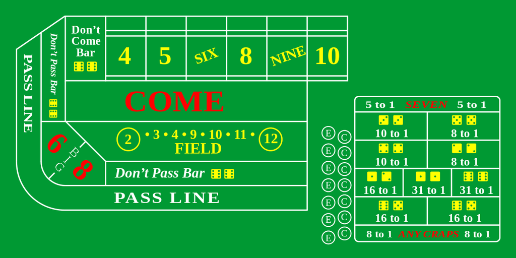

By Betzaar.com - http://betzaar.com/craps, [CC BY-SA 3.0](http://creativecommons.org/licenses/by-sa/3.0), https://commons.wikimedia.org/w/index.php?curid=12027168

If the come out roll is any other number (4, 5, 6, 8, 9, or 10), then that number is called the shooter’s point, and the shooter rolls the dice repeatedly until either a 7 or the shooter’s point is rolled again. If the shooter rolls a 7 before rolling point, all bets in the PASS LINE are lost. If the shooter rolls point before rolling a 7, the bank/casino pays all bets in the PASS LINE to the players. Write a function that simulates the outcomes from pass line betting in bank/casino craps.

The function `SIMcraps` consists of two basic parts. The first part is the function `linebet`, which simulates winning or losing a line bet in bank/casino craps. The second part is a `for` loop that runs the function `linebet` a fixed number of times, then computes the percent of games out of the total number of games simulated that resulted in a win for the shooter.

```r
SIMcraps <- function(n.games = 10000){
  opar <- par(no.readonly = TRUE)
  options(scipen=999)  # Suppress scientific notation in the output
  # linebet returns 0 or 1 based on whether 'shooter' loses or wins
  linebet <- function(){
    comeoutroll <- sum(sample(1:6, 2, replace = TRUE))  # first throw
    if (comeoutroll %in% c(7, 11)){
      result <- 1  # win if comeoutroll is 7 or 11
    } else if (comeoutroll %in% c(2, 3, 12)) {
      result <- 0  # loss if comeoutroll is 2, 3, or 12
    } else {
      repeat{
        substhrow <- sum(sample(1:6, 2, replace = TRUE))
        # subsequent throw
        if(substhrow == comeoutroll){
          result <- 1  # win if substhrow same as comeoutroll
          break
        } else if (substhrow == 7){
          result <- 0 # loss if substhrow is a 7
          break
        }
      }
    }
    result
  }
  gameOutcome <- numeric(n.games)  # vector of 0s of length n.games
  # Play n.games simulated crap games
  for(i in 1:n.games){gameOutcome[i] <- linebet()}
  # gameOutcomes is a vector of wins and losses
  P.win <- mean(gameOutcome)       # Percent of time shooter wins
  Actual.answer <- 244/495
  Error <- round(abs(Actual.answer - P.win)/Actual.answer * 100, 4)
  cat("Simulated probability of winning =",  P.win, "based on",
      n.games, "simulated games.", "\n")
  cat("Percent simulation error based on actual answer 244/495 is ",
      Error,"%.", "\n", sep="")
  par(opar)
  options(scipen = 0)
}
```

Running the function:

```r
set.seed(1234)  # setting seed for reproducibility
SIMcraps(n.games = 50000)
```

```
Simulated probability of winning = 0.49188 based on 50000 simulated games.
Percent simulation error based on actual answer 244/495 is 0.2129%.
```

The actual answer is $244/495$.